# Session 3: Pre-processing of Illumina Raw Reads

Apollo Marco Lizano; Le Qin Choo

2025-03-17

## 1. Demultiplexing Illumina Reads

Demultiplexing is the process of separating sequencing reads from a pooled sample based on barcode sequences. In Illumina sequencing, barcodes are embedded in the raw read files (usually BCL files), and demultiplexing converts them into FASTQ files for downstream analysis.

In this tutorial, we will use a prewritten program from Illumina and Rstudio to facilitate the demultiplexing process using tools like **bcl2fastq** and perform quality checks with **FastQC**.

Download bcl2fastq.sh script from Illumina page: https://support.illumina.com/sequencing/sequencing_software/bcl2fastq-conversion-software/downloads.html

Please make sure to check for the latest version.

**Input files:**

Path to the directory containing all .bcl files. SampleSheet.csv (includes individual barcodes and sample names from the Illumina run). A sample CSV file and a shell script (bcl2fastq.sh) for running the conversion commands are included in this folder.

To explore the contents of the folder, try using:

```bash
less E6609_SampleSheet.csv
```

[output not shown]

This `.csv` file was used to demultiplex my zooplankton samples, as the Illumina reads from our milkfish samples have already been demultiplexed.

## Running bcl2fastq

```bash
bcl2fastq --runfolder-dir /path/to/run/folder \
  --output-dir /path/to/output/folder \
  --sample-sheet SampleSheet.csv \
  --no-lane-splitting
```

## 2. Quality Control

FastQC and MultiQC are both essential tools in bioinformatics for quality control and summary reporting of sequencing data. Both are effective in checking the quality of the raw Illumina reads after demultiplexing.

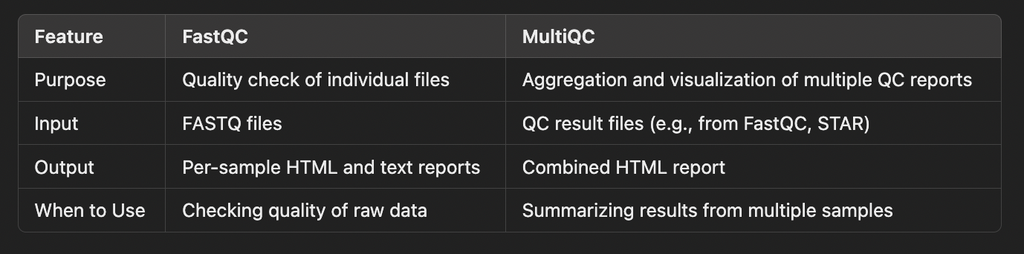

Fig 1. Summary of FastQC & MultiQC .

FastQC & MultiQC are already installed on our system, so there’s no need to worry about installation during this workshop. You’re all set to start analyzing your data.

Run FastQC on each samples using this command:

```bash
fastqc name_of_file.fastq.gz

or

ran it to the whole .fastq.gz files

fastqc *.fastq.gz
```

Then compile all the reports into one `.html` file using MultiQC

```bash
multiqc .
```

Check the output file. What did you see?

## 3. Adapter & Quality trimming

Removing adapters and trimming low-quality reads are essential steps before SNP calling to ensure high-quality downstream analysis. In this tutorial, we will use the software `cutadapt` to remove Illumina adapters and any remnants of individual barcode sequences.

To run `cutadapt`, use the following syntax:

```bash
cutadapt -a GATCGGAAGAGCACACGTCTGAACTCCAGTCAC \
-A AGATCGGAAGAGCGTCGTGTAGGGAAAGAGTGTAGATCTCGGTGGTCGCCGTATCATT -o outputfilename_R1_trimmed.fastq.gz \
-p  outputfilename_R2_trimmed.2.fastq.gz inputfilename_R1.fastq inputfilename_R2.fastq.gz
```

Try and run this to the `.fastq.gz` files on your directory

### Challenge:

Can you create a bash for loop that automatically run `cutadapt` to all the files?

Try to answer it first before scrolling down! Clue: AI is your friend :)

Answer:

```bash
#!/bin/bash
##Read filtering###

for i in *_1.fastq.gz
do
    base=$(basename "$i" _1.fastq.gz)
    cutadapt -a GATCGGAAGAGCACACGTCTGAACTCCAGTCAC \
    -A AGATCGGAAGAGCGTCGTGTAGGGAAAGAGTGTAGATCTCGGTGGTCGCCGTATCATT \
    -o "${base}_1_trimmed.fastq.gz" \
    -p "${base}_2_trimmed.fastq.gz" "$i" "${base}_2.fastq.gz"
done
```

Did we get the same answer? If we do, try running this shell script on your directory.

## 4 Post-trimming quality control

Before proceeding, we need to visualize whether there is any change or improvement in our .fastq.gz files. To do this, run fastqc again—this time on the trimmed reads.

```bash
fastqc *_trimmed.fastq.gz
```

What do you think? Did trimming and removing adapters improved our sequencing reads?

Reminder: Make sure that the size of paired-end files are the same before proceeeding

## 5 Read filtering (optional)

The final step to ensure that our input reads are of high quality before SNP calling is to remove contaminant sequences. This step is optional but highly recommended, especially for species of interest with known contaminants or symbionts.

For this tutorial, we will use `BBduk` from `BBtools` to perform contaminant removal. However, we will not run this step in our tutorial since milkfish do not have known potential contaminants aside from humans or coffee.

You can use to`bbduk` -h to optimize the parameters below:

```bash
bbduk.sh in1=trimmed_R1.fastq.gz in2=trimmed_R2.fastq.gz out1=filtered_R1.fastq.gz out2=filtered_R2.fastq.gz ref=adapters.fa ktrim=r k=23 mink=11 hdist=1 qtrim=rl trimq=20 minlen=50
```

# Now our filtered Illumina sequencing reads are now ready for SNP calling!!!